# Análisis del servicio de alojamiento de Airbnb en nueve ciudades de Europa del 2023

### Desarrollo :

- **Conocer el total de las ciudades que pertenecen a la base de datos**

```r
c <- table(D2$Ciudad)
sum(c)
```

```
[1] 41714
```

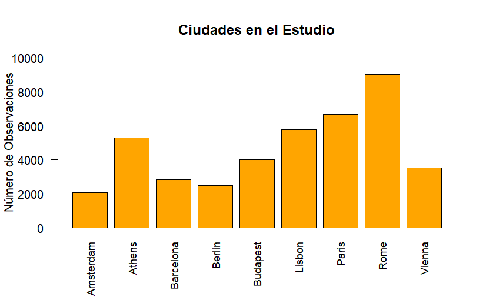

```r
barplot(c, main = "Ciudades en el Estudio", ylab = "Número de Observaciones" , las=2, ylim = c(0,10000), cex.names = 0.9, col=c("orange"))
```

```r
NA
NA
```

- **El precio promedio en todas las ciudades de Europa:**

```r
s <-round(mean(D2$Precio),digits = 2)
s
```

```
[1] 260.09
```

*El precio de los alojamientos se encuentran alrededor de los 260.09 dólares.*

- **Conocer la mediana del precio de los alojamientos**

````
```r
mediana_precio <- median(D2$Precio)
mediana_precio
```
````

````
```
[1] 203.8193
```
````

*Se concluye que a la mitad de los alojamientos que superen este valor, se les considera cómo la mitad con precios más caros. La parte inferior se consideran cómo airbnb’s económicos.*

*Al analizar estos 2 descriptores para la variable precio, se observa que la media es mayor a la mediana (sesgado a la derecha, quiere decir que el lado derecho tiene pocas observaciones , osea que los alojamiento con precios muy altos son pocos con respecto al total)*

- **Identificar cuáles son las observaciones que se encuentran por arriba de la mediana : “CARO”**

*Tenemos un total de 20,855 airbnb’s con precios mayores a los 203.8193 (mediana)*

```r
D2 %>% filter(Precio > mediana_precio) %>% arrange(desc(Precio)) -> CAROS
CAROS
```

[output not shown]

[output cut: 990 more lines]

```r
nrow(CAROS)
```

```
[1] 20855
```

```r
c1 <- table(CAROS$Ciudad) #Del grupos de los Caros, Atenas es el que menos alojamientos tiene en el estudio (795). El de más apariciones es París (5,724)
c1
```

```
Amsterdam    Athens Barcelona    Berlin  Budapest    Lisbon     Paris      Rome    Vienna
     2024       795      1453      1108       931      3465      5724      3512      1843
```

```r
min(c1)
```

```
[1] 795
```

```r
which.min(c1)
```

```
Athens
     2
```

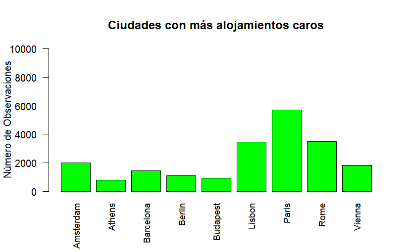

```r
barplot(c1, main = "Ciudades con más alojamientos caros", ylab = "Número de Observaciones" , las=2, ylim = c(0,10000), cex.names = 0.9, col=c("green"))
```

*ANÁLISIS : Del grupo de los Caros, Atenas es el que menos alojamientos tiene en el estudio (795 airbnb´s). El de más apariciones es París (5,724), seguido por Roma y Lisboa. Se concluye que París es la ciudad con mayor cantidad de alojamiento con precios elevados.*

*Analizamos los 100 alojamientos más caros :*

```r
#Analizamos el lado de  los 100 alojamientos más caros :

CAROS[1:100, ] -> CAROS100
CAROS100

#Qué ciudad aparece más aquí en alojamientos caros :
ciudades_100 <- table(CAROS100$Ciudad)
ciudades_100
barplot(ciudades_100, main = "Ubicación de las 100 ciudades con precios más caros", col= c("skyblue"),, las=2, cex.names = 0.9)

superhost100 <- table(CAROS100$Superhost)
barplot(superhost100, main = 'Superhost', col =c( "#CCFF99","#9999FF" ))
legend("topright",legend=c("SÍ","NO"),
       fil=c("#9999FF","#CCFF99"))


#Los valores de Limpieza y Satisfacción son muy altos
"La calificación que le asignan a este tipo de alojaminetos es 9.5 en promedio en LIMPIEZA"
mean(CAROS100$Limpieza)
"La Satisfacción del servicio es una notación alta, ya que tiene un 95.19 en promedio"
mean(CAROS100$Satisfaccion)
"Y lo mínimo en satisfacción es 60, lo que igual es alto"
min(CAROS100$Satisfaccion)
```

*ANÁLISIS :*

*En la segunda gráfica, se concluye que no necesariamente en airbnb costoso tendrá cómo anfitrión a un Superhost, ya que la mayoría es NO.*

*Además, según la tabla de abajo, la limpieza y la satisfacción son muy buenas ya que ambas presentan altos valores*

[output not shown]

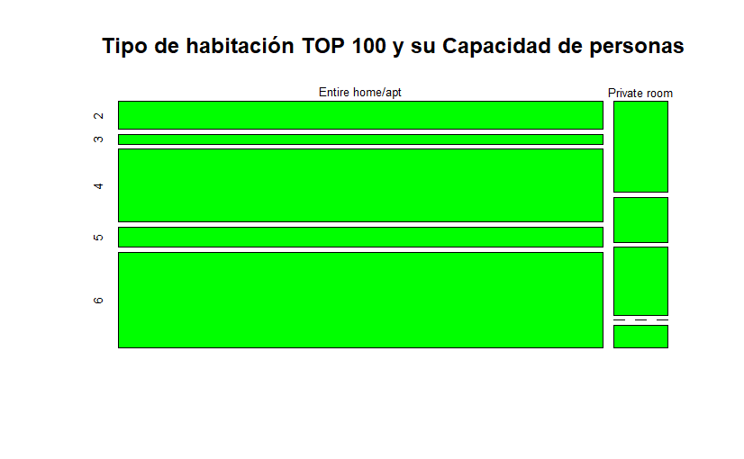

```r
tipo_capacidad <- table(CAROS100$Tipo,CAROS100$Capacidad)

mosaicplot(tipo_capacidad, main = "Tipo de habitación TOP 100 y su Capacidad de personas", color = "green")
```

*ANÁLISIS : Analizamos el tipo de cuarto y su capacidad de personas : La mayoría es una Casa Entera para 6, y tiene sentido por un costo elevado.*

```r
"La cantidad promedio de habitaciones en este tipo de alojamientos es:"
roundF(mean(CAROS100$Habitaciones, na.rm = T))

day <- table(CAROS100$Day) # Y se suelen tomar los fines de semana
day
mosaicplot(day, main = "Cual es el día en que más se reserva este tipo de alojamientos", color = "skyblue")
legend("bottomleft",legend=c("Weekday = 49","Weekend = 51"))
```

*ANÁLISIS : Se concluye este tipo de airbnb top 100, los suelen reservar tanto en días de semana cómo en fines.La diferencia es mínima y la cantidad promedio en número de habitaciones en este tipo de alojamientos es 3*

- **Identificar cuáles son las observaciones que se encuentran por debajo de la mediana : “ECO”**

```r
D2 %>% filter(Precio < mediana_precio) %>% arrange(Precio)-> ECO
ECO
```

[output not shown]

[output cut: 990 more lines]

```r
nrow(ECO)
```

```
[1] 20856
```

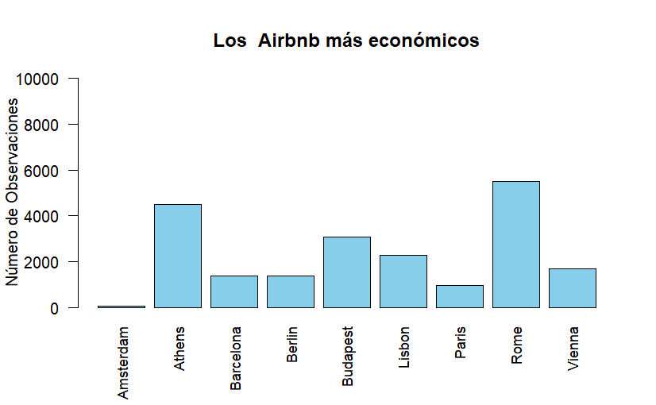

```r
barplot(table(ECO$Ciudad),main = "Los  Airbnb más económicos", ylab = "Número de Observaciones" , las=2, ylim = c(0,10000), cex.names = 0.9, col=c("skyblue"))
```

ANÁLISIS : *Es el total de Airbnb con precios menores a los 203.8193 (mediana) son 20,856 y el más económico tiene un costo de 34.77 dólares en Budapest, que consiste en una habitación privada para 2 personas. Este costo se podría asociar a que se encuentra a largas distancias del centro y del metro, además de un bajo índice de atracción.La relación entre estas variables se analiza en los siguientes puntos*